# pH_method

```r
library(googledrive)
library(tidyverse)
```

```r
library(ggplot2)
```

```r
dg_output = drive_get("Lila_Sarif_shaking_experiment", shared_drive = 'Bogar Lab')
```

[output not shown]

[output not shown]

[output not shown]

[output not shown]

[output not shown]

```
## ✔ The input `path` resolved to exactly 1 file.
```

```r
local_path <- paste0("Inputs/Lila_Sarif_shaking_experiment_downloaded-", format(Sys.Date(), "%Y%m%d"), ".csv") #define what this local file name will be, with today's date

drive_download(dg_output, type = "csv", path = local_path, overwrite = TRUE)
```

```
## File downloaded:
```

```
## • 'Lila_Sarif_shaking_experiment'
##   <id: 1LWNI9aByeKH7zn9y2FsJ4zKF0dsiMjv1mpvd_5Yg-1M>
```

```
## Saved locally as:
```

```
## • 'Inputs/Lila_Sarif_shaking_experiment_downloaded-20260730.csv'
```

```r
shaking_experiment_data = read.csv("Inputs/Lila_Sarif_shaking_experiment_downloaded-20260728.csv")
```

```r
shaking_experiment_data
```

```
##    Sample_ID shake_time_min temp_C_measured   pH trial_type
## 1      blank             20            22.3 5.20 as_planned
## 2    DSC_004             20            22.3 5.11 as_planned
## 3    DSC_003             20            22.3 5.00 as_planned
## 4    DSC_002             20            22.3 4.99 as_planned
## 5      blank             20            22.3 5.09 as_planned
## 6    DSC_004             20            22.3 5.05 as_planned
## 7    DSC_003             20            22.3 4.94 as_planned
## 8    DSC_002             20            22.3 4.96 as_planned
## 9      blank             20            23.5 5.01     decant
## 10   DSC_004             20            23.3 4.98     decant
## 11   DSC_003             20            23.5 4.91     decant
## 12   DSC_002             20            23.3 4.90     decant
## 13     blank             20            23.3 5.05     decant
## 14   DSC_004             20            23.2 5.02     decant
```

[output cut: 115 more lines]

```r
per_tube = shaking_experiment_data %>%
  unite("tube", c(Sample_ID, shake_time_min), sep = "_", remove = FALSE)

per_tube
```

```
##           tube Sample_ID shake_time_min temp_C_measured   pH trial_type
## 1     blank_20     blank             20            22.3 5.20 as_planned
## 2   DSC_004_20   DSC_004             20            22.3 5.11 as_planned
## 3   DSC_003_20   DSC_003             20            22.3 5.00 as_planned
## 4   DSC_002_20   DSC_002             20            22.3 4.99 as_planned
## 5     blank_20     blank             20            22.3 5.09 as_planned
## 6   DSC_004_20   DSC_004             20            22.3 5.05 as_planned
## 7   DSC_003_20   DSC_003             20            22.3 4.94 as_planned
## 8   DSC_002_20   DSC_002             20            22.3 4.96 as_planned
## 9     blank_20     blank             20            23.5 5.01     decant
## 10  DSC_004_20   DSC_004             20            23.3 4.98     decant
## 11  DSC_003_20   DSC_003             20            23.5 4.91     decant
## 12  DSC_002_20   DSC_002             20            23.3 4.90     decant
## 13    blank_20     blank             20            23.3 5.05     decant
## 14  DSC_004_20   DSC_004             20            23.2 5.02     decant
```

[output cut: 115 more lines]

How different were the repeat measurments of each prepared tube with a given method (“trial_type”)?

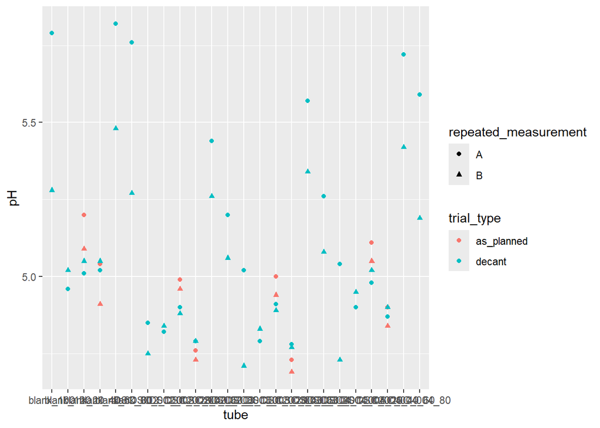

```r
ggplot(per_tube, aes(x = tube, y = pH, color = trial_type, shape = repeated_measurement)) +
  geom_point()
```

```r
w_diff = per_tube %>%
  pivot_wider(
    names_from = repeated_measurement, # Column providing 'A' and 'B'
    values_from = !c(tube, Sample_ID, shake_time_min, trial_type)            # all but these, which are constant for a given tube
  ) %>%
  mutate(diff = abs(pH_A - pH_B))

w_diff
```

```
## # A tibble: 32 × 13
##    tube  Sample_ID shake_time_min trial_type temp_C_measured_A temp_C_measured_B
##    <chr> <chr>              <int> <chr>                  <dbl>             <dbl>
##  1 blan… blank                 20 as_planned              22.3              22.3
##  2 DSC_… DSC_004               20 as_planned              22.3              22.3
##  3 DSC_… DSC_003               20 as_planned              22.3              22.3
##  4 DSC_… DSC_002               20 as_planned              22.3              22.3
##  5 blan… blank                 20 decant                  23.5              23.3
##  6 DSC_… DSC_004               20 decant                  23.3              23.2
##  7 DSC_… DSC_003               20 decant                  23.5              23.3
##  8 DSC_… DSC_002               20 decant                  23.3              23.3
##  9 blan… blank                 40 as_planned              22.1              22.1
## 10 DSC_… DSC_004               40 as_planned              22.1              22.1
## # ℹ 22 more rows
## # ℹ 7 more variables: pH_A <dbl>, pH_B <dbl>, repeated_measurement_A <chr>,
## #   repeated_measurement_B <chr>, notes_A <chr>, notes_B <chr>, diff <dbl>
```

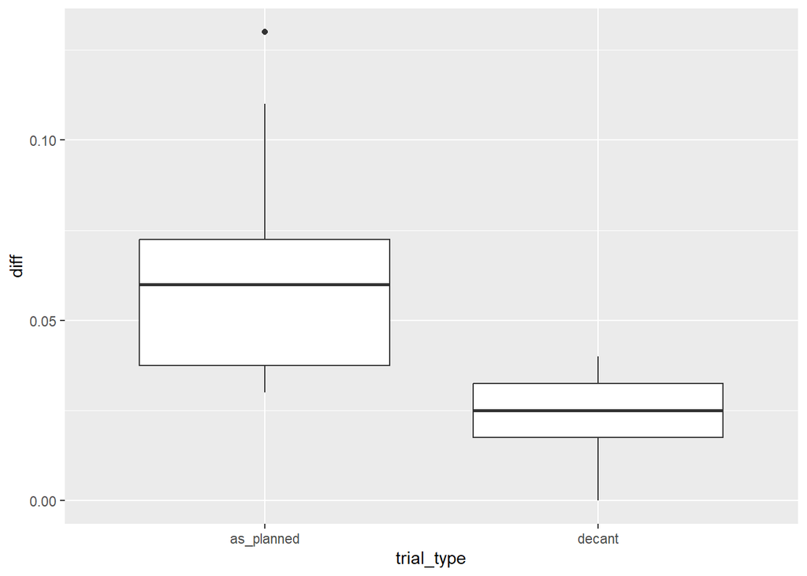

```r
# for time points where we were comparing methods, compare the difference between two measurements of an identical pH tube based on method
ggplot(w_diff %>% filter (shake_time_min == 20 | shake_time_min == 40), aes(x = trial_type, y = diff)) + geom_boxplot()
```

How did measurements, and differences between repeat measurements, change over shaking time?

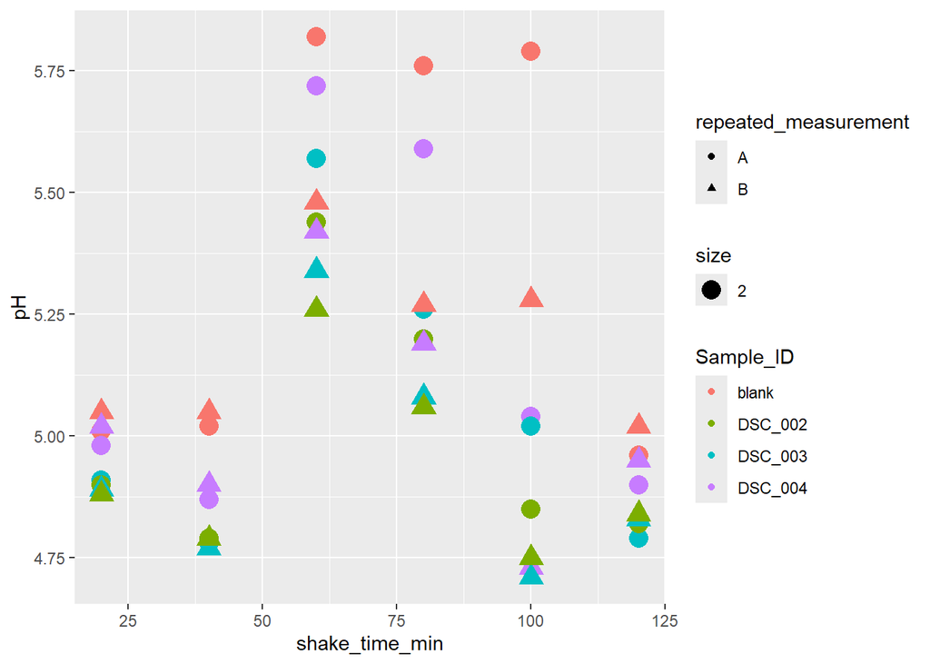

```r
# with only the method that was consistent across all time points ("decant" is the method that measured temperature), compare pH of soil from same original samples over time

ggplot((per_tube %>% filter(trial_type != "as_planned")), aes(x = shake_time_min, y = pH, color = Sample_ID, shape = repeated_measurement, size = 2)) +
  geom_point()
```

Concerns: - CaCl2 was impure (90% salt); blank pHs should be closer to 7 than this - Maybe not enough rinsing of electrode at 60, 80, and 100 minutes? - In 20, 40, and 120 minute cases, triangles (2nd repeat measurement) are above circles (1st repeat measurement). Solution reads less acidic on second measurement, but not by much. These time points, Sarif was present for/doing many of the measurements. In 60, 80, and 100, circles (1st repeat measurement) are above triangels (2nd repeat measurement). Solution reads more acidic on second measurement, often by much more. Are remnants of soil solution lowering the pH of the blank, and subsequent soil measurements? - 60-120 min soltions sat on the bench for a long time after shaking/decanting.

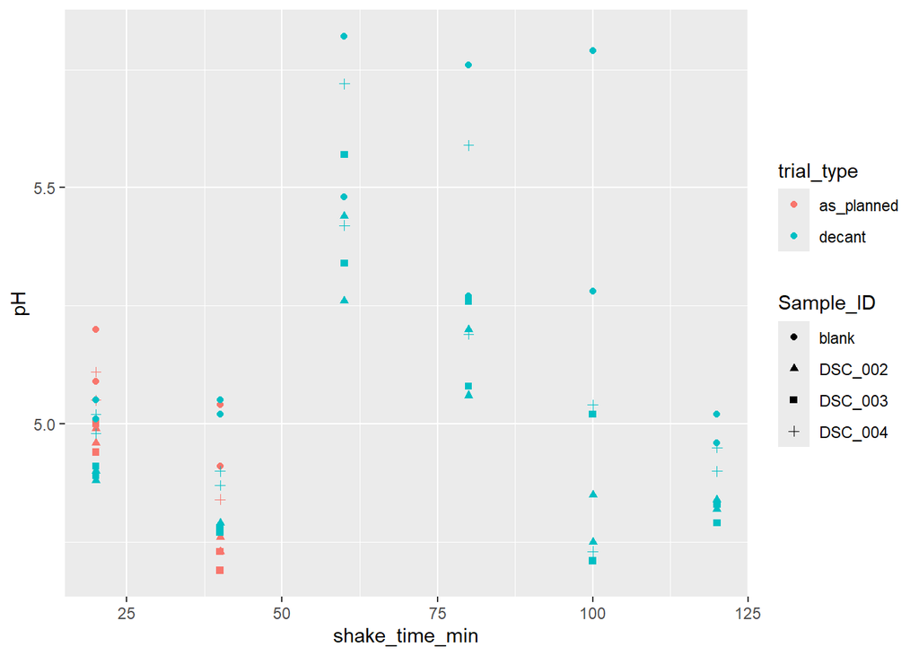

```r
ggplot(per_tube, aes(x = shake_time_min, y = pH, color = trial_type, shape = Sample_ID)) +
  geom_point()
```

```r
decant_only = shaking_experiment_data %>%
  filter(trial_type == "decant")

decant_only
```

```
##    Sample_ID shake_time_min temp_C_measured   pH trial_type
## 1      blank             20            23.5 5.01     decant
## 2    DSC_004             20            23.3 4.98     decant
## 3    DSC_003             20            23.5 4.91     decant
## 4    DSC_002             20            23.3 4.90     decant
## 5      blank             20            23.3 5.05     decant
## 6    DSC_004             20            23.2 5.02     decant
## 7    DSC_003             20            23.3 4.89     decant
## 8    DSC_002             20            23.3 4.88     decant
## 9      blank             40            23.6 5.02     decant
## 10   DSC_004             40            23.8 4.87     decant
## 11   DSC_003             40            23.6 4.78     decant
## 12   DSC_002             40            23.5 4.79     decant
## 13     blank             40            23.6 5.05     decant
## 14   DSC_004             40            23.7 4.90     decant
```

[output cut: 83 more lines]

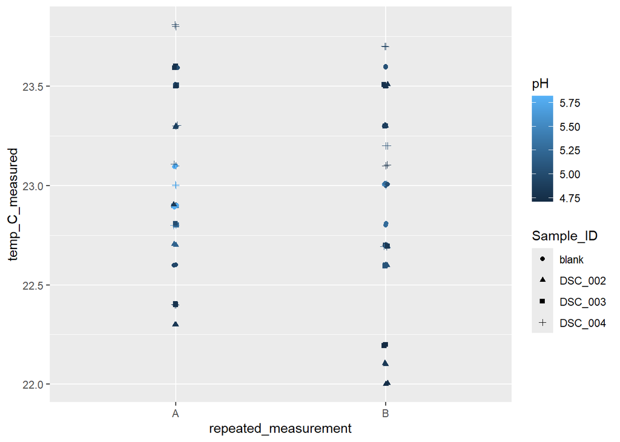

```r
ggplot(decant_only, aes(x = repeated_measurement, y = temp_C_measured, color = pH, shape = Sample_ID)) +
  geom_point() + geom_jitter(width = 0.01, height = 0.01)
```

```r
dg_output = drive_get("Lila_shaking_experiment_transcribed_20260729", shared_drive = 'Bogar Lab')
```

```
## ✔ The input `path` resolved to exactly 1 file.
```

```r
local_path <- paste0("Lila_shaking_experiment_20260729_downloaded-", format(Sys.Date(), "%Y%m%d"), ".csv") #define what this local file name will be, with today's date

drive_download(dg_output, type = "csv", path = local_path, overwrite = TRUE)
```

```
## File downloaded:
```

```
## • 'Lila_shaking_experiment_transcribed_20260729'
##   <id: 1fnI5YhKb_3KmNIy3qO8PoBLi-ByIfCWs3DiKU6xC5jg>
```

```
## Saved locally as:
```

```
## • 'Lila_shaking_experiment_20260729_downloaded-20260730.csv'
```

```r
shaking_experiment_2_data = read.csv(local_path)
```

```r
per_tube_2 = shaking_experiment_2_data %>%
  unite("tube", c(Sample_ID, shake_time_min), sep = "_", remove = FALSE)

per_tube_2
```

```
##          tube Sample_ID shake_time_min temp_C_measured   pH
## 1   blank _30    blank              30            22.1 5.88
## 2  DSC_004_30   DSC_004             30            22.1 5.52
## 3  DSC_003_30   DSC_003             30            22.4 5.23
## 4  DSC_002_30   DSC_002             30            22.4 5.18
## 5   blank _30    blank              30            22.2 5.31
## 6  DSC_004_30   DSC_004             30            22.2 5.16
## 7  DSC_003_30   DSC_003             30            22.3 4.88
## 8  DSC_002_30   DSC_002             30            22.3 4.90
## 9   blank _60    blank              60            22.0 5.15
## 10 DSC_004_60   DSC_004             60            21.7 4.93
## 11 DSC_003_60   DSC_003             60            21.7 4.83
## 12 DSC_002_60   DSC_002             60            22.4 4.84
## 13  blank _60    blank              60            22.3 5.02
## 14 DSC_004_60   DSC_004             60            21.9 4.89
```

[output cut: 35 more lines]

How different were the repeat measurments of each prepared tube with a given method (“trial_type”)?

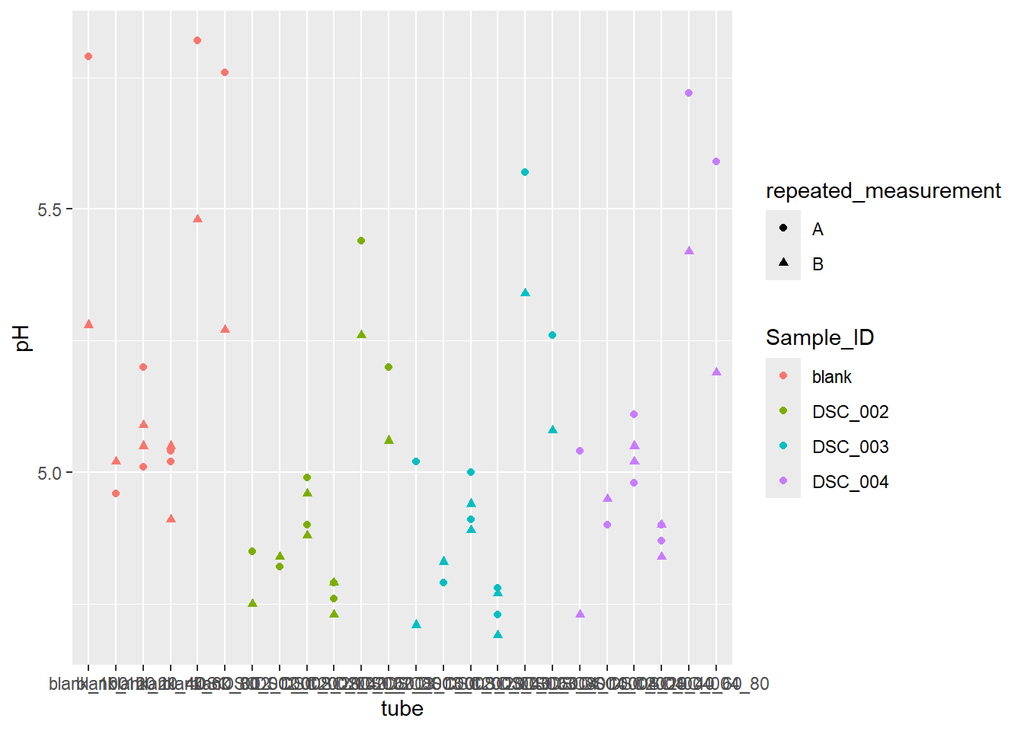

```r
ggplot(per_tube, aes(x = tube, y = pH, color = Sample_ID, shape = repeated_measurement)) +
  geom_point()
```

How did measurements, and differences between repeat measurements, change over shaking time?

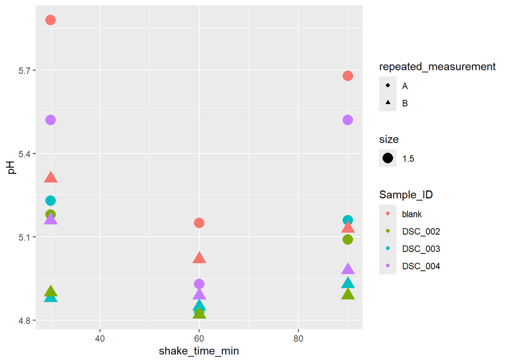

```r
# with only the method that was consistent across all time points ("decant" is the method that measured temperature), compare pH of soil from same original samples over time

ggplot((per_tube_2), aes(x = shake_time_min, y = pH, color = Sample_ID, shape = repeated_measurement, size = 1.5)) +
  geom_point()
```

```r
w_diff_2 = per_tube_2 %>%
  pivot_wider(
    names_from = repeated_measurement, # Column providing 'A' and 'B'
    values_from = !c(tube, Sample_ID, shake_time_min)            # all but these, which are constant for a given tube
  ) %>%
  mutate(diff = abs(pH_A - pH_B))

w_diff_2
```

```
## # A tibble: 12 × 12
##    tube       Sample_ID shake_time_min temp_C_measured_A temp_C_measured_B  pH_A
##    <chr>      <chr>              <int>             <dbl>             <dbl> <dbl>
##  1 blank _30  "blank "              30              22.1              22.2  5.88
##  2 DSC_004_30 "DSC_004"             30              22.1              22.2  5.52
##  3 DSC_003_30 "DSC_003"             30              22.4              22.3  5.23
##  4 DSC_002_30 "DSC_002"             30              22.4              22.3  5.18
##  5 blank _60  "blank "              60              22                22.3  5.15
##  6 DSC_004_60 "DSC_004"             60              21.7              21.9  4.93
##  7 DSC_003_60 "DSC_003"             60              21.7              22    4.83
##  8 DSC_002_60 "DSC_002"             60              22.4              22.1  4.84
##  9 blank _90  "blank "              90              22.1              22.2  5.68
## 10 DSC_004_90 "DSC_004"             90              22.4              22    5.52
## 11 DSC_003_90 "DSC_003"             90              22.3              22    5.16
## 12 DSC_002_90 "DSC_002"             90              22.3              22.1  5.09
## # ℹ 6 more variables: pH_B <dbl>, repeated_measurement_A <chr>,
## #   repeated_measurement_B <chr>, notes_A <lgl>, notes_B <lgl>, diff <dbl>
```

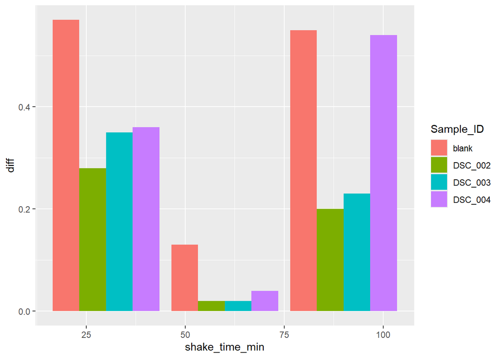

```r
ggplot(w_diff_2, aes(x = shake_time_min, y = diff, fill = Sample_ID)) +
  geom_bar(stat = "identity",
           position = position_dodge())
```

Measurements from yesterday and today together:

```r
w_diff_1 = w_diff %>%
  filter(trial_type != "as_planned") %>%
  select(!trial_type) %>%
  mutate(experiment_day = "tues")

per_tube_1 = per_tube %>%
  filter(trial_type != "as_planned") %>%
  select(!trial_type) %>%
  mutate(experiment_day = "tues")

w_diff_2 = w_diff_2 %>%
  mutate(experiment_day = "weds")

per_tube_2 = per_tube_2 %>%
  mutate(experiment_day = "weds")

bothdays_w_diff = rbind(w_diff_1, w_diff_2)

bothdays_per_tube = rbind(per_tube_1, per_tube_2)
```

How did measurements, and differences between repeat measurements, change over shaking time?

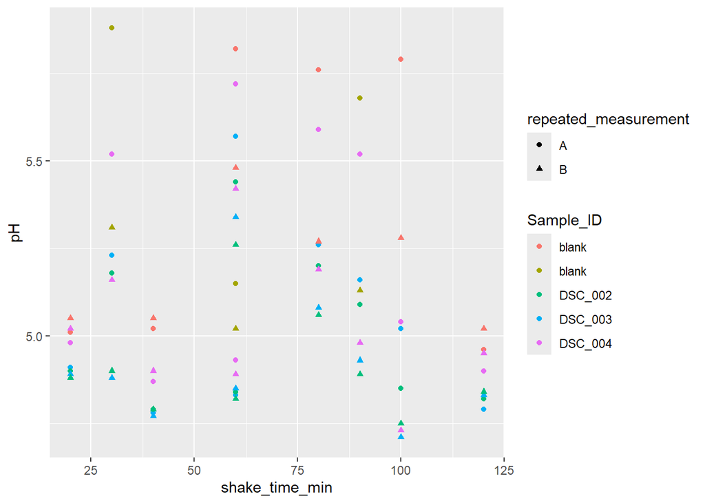

```r
# with only the method that was consistent across all time points ("decant" is the method that measured temperature), compare pH of soil from same original samples over time

ggplot((bothdays_per_tube), aes(x = shake_time_min, y = pH, color = Sample_ID)) +
  geom_point(aes(shape = repeated_measurement))
```

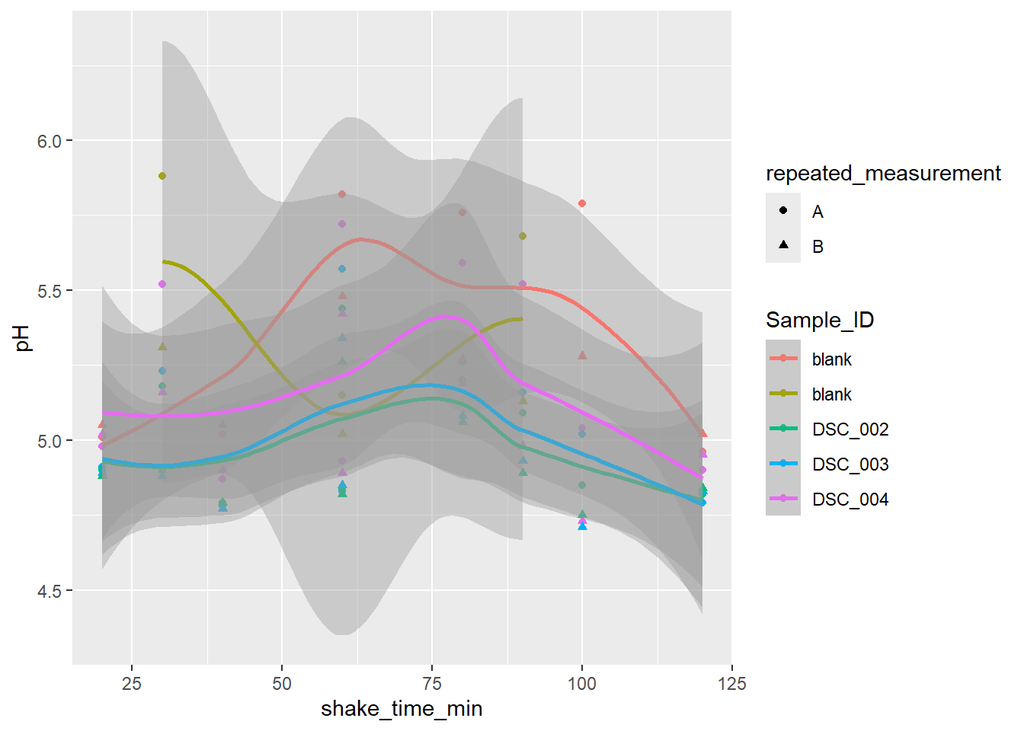

```r
ggplot((bothdays_per_tube), aes(x = shake_time_min, y = pH, color = Sample_ID)) +
  geom_point(aes(shape = repeated_measurement)) +
  geom_smooth(method = "loess")
```

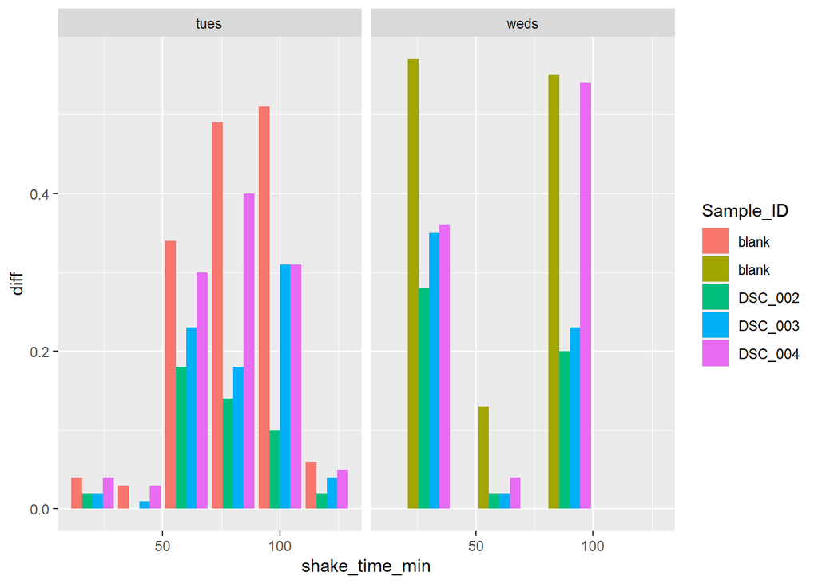

```r
ggplot(bothdays_w_diff, aes(x = shake_time_min, y = diff, fill = Sample_ID)) +
  geom_bar(stat = "identity",
           position = position_dodge()) +
  facet_wrap(vars(experiment_day))
```

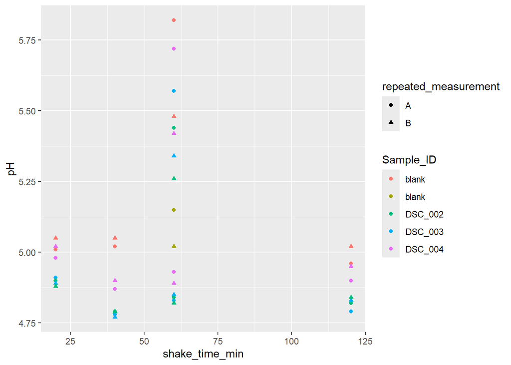

```r
low_diff_only = bothdays_per_tube %>%
  filter(shake_time_min == 20 |
           shake_time_min == 40 |
           shake_time_min == 60 |
           shake_time_min == 120)


ggplot((low_diff_only), aes(x = shake_time_min, y = pH, color = Sample_ID)) +
  geom_point(aes(shape = repeated_measurement))
```